# Lab 9

Rob Kravec

October 19, 2020

## Introduction

A database is a structured set of data. Terminology is a little bit different when working with a database management system compared to working with data in R.

- field: variable or quantity
- record: collection of fields
- table: collection of records with all the same fields
- database: collection of tables

The relationship between R terminology and database terminology is explained below.

| **R terminology** | **Database terminology** |
| --- | --- |
| column | field |
| row | record |
| data frame | table |
| types of columns | table schema |
| collection of data frames | database |

SQL (structured query language) allows you to directly interact with a database and perform tasks such as pull data and make updates. R has two packages available that make it easy to run SQL queries: `DBI` and `RSQLite`.

## Packages

To get started, load packages `DBI`, `RSQLite`, `tidyverse`, and `Lahman`. Install any packages by entering command `install.packages("package")` in your Console pane.

Package `DBI` provides a database interface for communication between R and relational database management systems. Package `RSQLite` embeds the SQLite database engine in R and provides an interface compliant with the package `DBI`.

```r
library(DBI)
library(RSQLite)
library(tidyverse)
library(Lahman)
```

## In-memory database

The below chunk of code will turn data frame `mtcars` into a table in the in-memory database that can be referenced by name `mtcarsdb`.

At the conclusion of this RMarkdown file there is a code chunk that closes the connection and frees resources. Run that chunk when you complete the document.

```r
con <- dbConnect(SQLite(), ":memory:")
dbWriteTable(con, "mtcarsdb", mtcars)

# see tables
dbListTables(con)
```

```
[1] "mtcarsdb"
```

## SQL to dplyr

#### Task 1

```r
dbGetQuery(con, paste("SELECT * FROM mtcarsdb",
                      "WHERE mpg > 20",
                      "ORDER BY cyl")
           )
```

| mpg | cyl | disp | hp | drat | wt | qsec | vs | am | gear | carb |
| --- | --- | --- | --- | --- | --- | --- | --- | --- | --- | --- |
| 22.8 | 4 | 108.0 | 93 | 3.85 | 2.320 | 18.61 | 1 | 1 | 4 | 1 |
| 24.4 | 4 | 146.7 | 62 | 3.69 | 3.190 | 20.00 | 1 | 0 | 4 | 2 |
| 22.8 | 4 | 140.8 | 95 | 3.92 | 3.150 | 22.90 | 1 | 0 | 4 | 2 |
| 32.4 | 4 | 78.7 | 66 | 4.08 | 2.200 | 19.47 | 1 | 1 | 4 | 1 |
| 30.4 | 4 | 75.7 | 52 | 4.93 | 1.615 | 18.52 | 1 | 1 | 4 | 2 |
| 33.9 | 4 | 71.1 | 65 | 4.22 | 1.835 | 19.90 | 1 | 1 | 4 | 1 |
| 21.5 | 4 | 120.1 | 97 | 3.70 | 2.465 | 20.01 | 1 | 0 | 3 | 1 |
| 27.3 | 4 | 79.0 | 66 | 4.08 | 1.935 | 18.90 | 1 | 1 | 4 | 1 |
| 26.0 | 4 | 120.3 | 91 | 4.43 | 2.140 | 16.70 | 0 | 1 | 5 | 2 |
| 30.4 | 4 | 95.1 | 113 | 3.77 | 1.513 | 16.90 | 1 | 1 | 5 | 2 |

[output cut: 4 more lines]

#### Task 2

```r
dbGetQuery(con, paste("SELECT mpg, wt, gear FROM mtcarsdb",
                      "WHERE mpg > 25 AND wt < 3",
                      "ORDER BY mpg DESC")
           )
```

| mpg | wt | gear |
| --- | --- | --- |
| 33.9 | 1.835 | 4 |
| 32.4 | 2.200 | 4 |
| 30.4 | 1.615 | 4 |
| 30.4 | 1.513 | 5 |
| 27.3 | 1.935 | 4 |
| 26.0 | 2.140 | 5 |

#### Task 3

```r
dbGetQuery(con, "SELECT COUNT(mpg) FROM mtcarsdb")
```

| COUNT(mpg) |
| --- |
| 32 |

#### Task 4

```r
dbGetQuery(con, paste("SELECT cyl, AVG(hp) FROM mtcarsdb",
                      "GROUP BY cyl",
                      "ORDER BY AVG(hp) DESC")
           )
```

| cyl | AVG(hp) |
| --- | --- |
| 8 | 209.21429 |
| 6 | 122.28571 |
| 4 | 82.63636 |

## SQL queries

Use function `dbGetQuery()` to write SQL queries for Tasks 5 - 8. Make use of function `paste()` to neatly format your SQL statement.

#### Task 5

Write a SQL query that returns 10 rows of the variables `mpg`, `gear`, and `carb`.

```r
dbGetQuery(con, paste("SELECT mpg, gear, carb",
                      "FROM mtcarsdb",
                      "LIMIT 10"))
```

| mpg | gear | carb |
| --- | --- | --- |
| 21.0 | 4 | 4 |
| 21.0 | 4 | 4 |
| 22.8 | 4 | 1 |
| 21.4 | 3 | 1 |
| 18.7 | 3 | 2 |
| 18.1 | 3 | 1 |
| 14.3 | 3 | 4 |
| 24.4 | 4 | 2 |
| 22.8 | 4 | 2 |
| 19.2 | 4 | 4 |

#### Task 6

Write a SQL query that returns the variables `mpg`, `gear`, and `carb` ordered in ascending order by `carb`.

```r
dbGetQuery(con, paste("SELECT mpg, gear, carb",
                      "FROM mtcarsdb",
                      "ORDER BY carb"))
```

| mpg | gear | carb |
| --- | --- | --- |
| 22.8 | 4 | 1 |
| 21.4 | 3 | 1 |
| 18.1 | 3 | 1 |
| 32.4 | 4 | 1 |
| 33.9 | 4 | 1 |
| 21.5 | 3 | 1 |
| 27.3 | 4 | 1 |
| 18.7 | 3 | 2 |
| 24.4 | 4 | 2 |
| 22.8 | 4 | 2 |

[output cut: 22 more lines]

#### Task 7

Write a SQL query that returns the variables `mpg`, `cyl`, and `carb`, where `carb` is greater than 2 and `cyl` is greater than 4.

```r
dbGetQuery(con, paste("SELECT mpg, cyl, carb",
                      "FROM mtcarsdb",
                      "WHERE carb > 2 AND cyl > 4"))
```

| mpg | cyl | carb |
| --- | --- | --- |
| 21.0 | 6 | 4 |
| 21.0 | 6 | 4 |
| 14.3 | 8 | 4 |
| 19.2 | 6 | 4 |
| 17.8 | 6 | 4 |
| 16.4 | 8 | 3 |
| 17.3 | 8 | 3 |
| 15.2 | 8 | 3 |
| 10.4 | 8 | 4 |
| 10.4 | 8 | 4 |

[output cut: 5 more lines]

#### Task 8

Write a SQL query that returns the mean `mpg`, mean `hp`, and mean `wt` grouped by `cyl` and then `carb`.

```r
dbGetQuery(con, paste("SELECT cyl, carb, avg(mpg) as avg_mpg,",
                      "avg(hp) as avg_hp, avg(wt) as avg_wt",
                      "FROM mtcarsdb",
                      "GROUP BY cyl, carb"))
```

| cyl | carb | avg_mpg | avg_hp | avg_wt |
| --- | --- | --- | --- | --- |
| 4 | 1 | 27.58 | 77.4 | 2.151000 |
| 4 | 2 | 25.90 | 87.0 | 2.398000 |
| 6 | 1 | 19.75 | 107.5 | 3.337500 |
| 6 | 4 | 19.75 | 116.5 | 3.093750 |
| 6 | 6 | 19.70 | 175.0 | 2.770000 |
| 8 | 2 | 17.15 | 162.5 | 3.560000 |
| 8 | 3 | 16.30 | 180.0 | 3.860000 |
| 8 | 4 | 13.15 | 234.0 | 4.433167 |
| 8 | 8 | 15.00 | 335.0 | 3.570000 |

## Joins with SQL

We may want to extract information from multiple tables. The `JOIN` option in your SQL query will help streamline this process.

There are 4 main types of join in SQL:

1. `INNER JOIN` or just `JOIN`: retain just the rows for each table that match the condition
2. `LEFT OUTER JOIN` or just `LEFT JOIN`: retain all rows in the first table, and just the rows in the second table that match the condition
3. `RIGHT OUTER JOIN` or just `RIGHT JOIN`: retain just the rows in the first table that match the condition, and all rows in the second table
4. `FULL OUTER JOIN` or just `FULL JOIN`: retain all rows in both tables

Fields that cannot be filled in are assigned `NA` values.

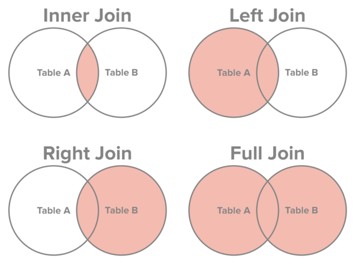

In package `dplyr` there are functions `left_join()`, `right_join()`, `inner_join()`, and `full_join()`, `semi_join()`, and `anti_join()`.

Let’s add some more tables to our in-memory database from the `Lahman` package.

```r
# add data frames in package Lahman to database
for (i in 1:dim(LahmanData)[1]) {
  dbWriteTable(con, LahmanData$file[i], get(LahmanData$file[i]))
}
```

To verify that all the data frames were added to the database we can run code

```r
# all tables
con %>%
  dbListTables()
```

```
 [1] "AllstarFull"         "Appearances"         "AwardsManagers"
 [4] "AwardsPlayers"       "AwardsShareManagers" "AwardsSharePlayers"
 [7] "Batting"             "BattingPost"         "CollegePlaying"
[10] "Fielding"            "FieldingOF"          "FieldingPost"
[13] "HallOfFame"          "Managers"            "ManagersHalf"
[16] "Master"              "Pitching"            "PitchingPost"
[19] "Salaries"            "Schools"             "SeriesPost"
[22] "Teams"               "TeamsFranchises"     "TeamsHalf"
[25] "mtcarsdb"
```

#### Example

Suppose we want a table that contains the 10 players with the highest career home run average. The table should also include each player’s average career salary. This information is across two tables in our database.

```r
# fields in batting
con %>%
  dbListFields(name = "Batting")
```

```
 [1] "playerID" "yearID"   "stint"    "teamID"   "lgID"     "G"
 [7] "AB"       "R"        "H"        "X2B"      "X3B"      "HR"
[13] "RBI"      "SB"       "CS"       "BB"       "SO"       "IBB"
[19] "HBP"      "SH"       "SF"       "GIDP"
```

```r
# fields in salaries
con %>%
  dbListFields(name = "Salaries")
```

```
[1] "yearID"   "teamID"   "lgID"     "playerID" "salary"
```

We can extract the information from both tables as a single table via JOIN on the pair: `yearID`, `playerID`. These variables form a key. The key uniquely identifies each row of a table.

To get what we want, use

```r
con %>%
  dbGetQuery(paste("SELECT playerID, AVG(HR), AVG(salary)",
                    "FROM Batting JOIN Salaries USING(yearID, playerID)",
                    "GROUP BY playerID",
                    "ORDER BY Avg(HR) DESC",
                    "LIMIT 10"))
```

| playerID | AVG(HR) | AVG(salary) |
| --- | --- | --- |
| bryankr01 | 39.00000 | 652000 |
| pujolal01 | 36.93750 | 12752527 |
| bondsba01 | 34.63636 | 8556606 |
| mcgwima01 | 34.29412 | 4814021 |
| arenano01 | 33.66667 | 2004167 |
| howarry01 | 33.30000 | 15525500 |
| troutmi01 | 33.25000 | 5919083 |
| duvalad01 | 33.00000 | 510000 |
| cartech02 | 32.75000 | 1919750 |
| kingmda01 | 32.50000 | 908750 |

We could have produced the same result with `dplyr` commands

```r
Batting %>%
  inner_join(Salaries, by = c("yearID", "playerID")) %>%
  group_by(playerID) %>%
  summarise(mean_hr = mean(HR),
            mean_salary = mean(salary)) %>%
  arrange(desc(mean_hr)) %>%
  slice(1:10)
```

| playerID | mean_hr | mean_salary |
| --- | --- | --- |
| bryankr01 | 39.00000 | 652000 |
| pujolal01 | 36.93750 | 12752527 |
| bondsba01 | 34.63636 | 8556606 |
| mcgwima01 | 34.29412 | 4814021 |
| arenano01 | 33.66667 | 2004167 |
| howarry01 | 33.30000 | 15525500 |
| troutmi01 | 33.25000 | 5919083 |
| duvalad01 | 33.00000 | 510000 |
| cartech02 | 32.75000 | 1919750 |
| kingmda01 | 32.50000 | 908750 |

#### Task 9

Use the `JOIN` option to merge the “Batting” and “Salaries” tables by matching `yearID` and `playerID`. Find the 10 players with the most strikeouts in a season since the year 2000. Also, display each player’s salary for that season in the resulting table.

```r
dbGetQuery(con, paste("SELECT a. playerID, a.SO, b.salary",
                      "FROM Batting as a",
                      "LEFT JOIN Salaries as b",
                      "ON a.playerID = b.playerID",
                      "AND a.yearID = b.yearID",
                      "WHERE a.yearID >= 2000",
                      "ORDER BY a.SO DESC",
                      "LIMIT 10"))
```

| playerID | SO | salary |
| --- | --- | --- |
| reynoma01 | 223 | 422500 |
| dunnad01 | 222 | 14000000 |
| davisch02 | 219 | 21268890 |
| moncayo01 | 217 | NA |
| cartech02 | 212 | 494000 |
| reynoma01 | 211 | 833333 |
| stantmi03 | 211 | NA |
| davisch02 | 208 | 12000000 |
| judgeaa01 | 208 | NA |
| gallojo01 | 207 | NA |

#### Task 10

Use the `JOIN` option to merge “Salaries” and “Teams” tables by matching `yearID` and `teamID`. Find the 10 highest salaries by team in 2016.

```r
dbGetQuery(con, paste("SELECT a.teamID, sum(b.salary) as sum_salary",
                      "FROM Teams as a",
                      "LEFT JOIN Salaries as b",
                      "ON a.teamID = b.teamID",
                      "AND a.yearID = b.yearID",
                      "WHERE a.yearID = 2016",
                      "GROUP BY a.teamID",
                      "ORDER BY sum_salary DESC",
                      "LIMIT 10"))
```

| teamID | sum_salary |
| --- | --- |
| NYA | 222997792 |
| LAN | 221288380 |
| DET | 194876481 |
| BOS | 188545761 |
| TEX | 176038723 |
| SFN | 172253778 |
| BAL | 161863456 |
| CHN | 154067668 |
| SLN | 143053500 |
| WAS | 141652646 |

## Close connection

```r
dbDisconnect(con)
```